# Project: Loan Data from Prosper

### Part I - Exploring the Prosper Loan Dataset

### By Naser Shanti

- Introduction
- Asking questions
- Definition of Variables
- Preliminary Wrangling
- Univariate Exploration
- Multivariate Exploration

## Introduction

### Dataset Description

> This dataset contains the customer's data from a loan company known as Prosper. This dataset comprises of 113,937 loans with 81 variables on each loan, including loan amount, borrower rate (or interest rate), current loan status, borrower income, and many others.

## Definition of Variables

> This will provide with a descrption about each variable in the dataset

### Listing Details

- **ListingKey**: Unique key for each listing, same value as the 'key' used in the listing object in the API.
- **ListingNumber**: The number that uniquely identifies the listing to the public as displayed on the website.
- **ListingCreationDate**: The date the listing was created.
- **Term**: The length of the loan expressed in months.
- **ListingCategory**: The category of the listing selected by the borrower:
  - `0`: Not Available
  - `1`: Debt Consolidation
  - `2`: Home Improvement
  - `3`: Business
  - `4`: Personal Loan
  - `5`: Student Use
  - `6`: Auto
  - `7`: Other
  - `8`: Baby & Adoption
  - `9`: Boat
  - `10`: Cosmetic Procedure
  - `11`: Engagement Ring
  - `12`: Green Loans
  - `13`: Household Expenses
  - `14`: Large Purchases
  - `15`: Medical/Dental
  - `16`: Motorcycle
  - `17`: RV
  - `18`: Taxes
  - `19`: Vacation
  - `20`: Wedding Loans

## Credit and Loan Status

- **CreditGrade**: The credit rating assigned at the time the listing went live. Applicable for listings pre-2009 and will only be populated for those listings.
- **LoanStatus**: The current status of the loan:
  - Cancelled
  - Chargedoff
  - Completed
  - Current
  - Defaulted
  - FinalPaymentInProgress
  - PastDue (accompanied by a delinquency bucket)
- **ClosedDate**: Applicable for Cancelled, Completed, Chargedoff, and Defaulted loan statuses.
- **LoanKey**: Unique key for each loan. Same key used in the API.
- **LoanOriginalAmount**: The origination amount of the loan.
- **LoanOriginationDate**: The date the loan was originated.
- **LoanOriginationQuarter**: The quarter in which the loan was originated.
- **LoanNumber**: Unique numeric value associated with the loan.
- **LoanMonthsSinceOrigination**: Number of months since the loan originated.
- **LoanCurrentDaysDelinquent**: The number of days delinquent.
- **LoanFirstDefaultedCycleNumber**: The cycle the loan was charged off. Null if the loan has not charged off.

## Borrower Information

- **BorrowerAPR**: The Borrower's Annual Percentage Rate (APR) for the loan.
- **BorrowerRate**: The Borrower's interest rate for this loan.
- **BorrowerState**: Two-letter abbreviation of the borrower's state at the time the listing was created.
- **Occupation**: The occupation selected by the borrower at the time they created the listing.
- **EmploymentStatus**: The employment status of the borrower at the time they posted the listing.
- **EmploymentStatusDuration**: Length in months of the employment status at the time the listing was created.
- **IsBorrowerHomeowner**: Classifies the borrower as a homeowner if they have a mortgage on their credit profile or provide documentation confirming homeownership.
- **CurrentlyInGroup**: Specifies whether the borrower was in a group at the time the listing was created.
- **GroupKey**: Key of the group the borrower is a member of. Null if no group affiliation.
- **DateCreditPulled**: Date the credit profile was pulled.
- **CreditScoreRangeLower**: Lower value representing the range of the borrower's credit score.
- **CreditScoreRangeUpper**: Upper value representing the range of the borrower's credit score.

## Credit Profile

- **FirstRecordedCreditLine**: Date the first credit line was opened.
- **CurrentCreditLines**: Number of current credit lines at the time the credit profile was pulled.
- **OpenCreditLines**: Number of open credit lines at the time the credit profile was pulled.
- **TotalCreditLinespast7years**: Number of credit lines in the past seven years.
- **OpenRevolvingAccounts**: Number of open revolving accounts.
- **OpenRevolvingMonthlyPayment**: Monthly payment on revolving accounts.
- **InquiriesLast6Months**: Number of inquiries in the past six months.
- **TotalInquiries**: Total number of inquiries.
- **CurrentDelinquencies**: Number of accounts delinquent.
- **AmountDelinquent**: Dollars delinquent.
- **DelinquenciesLast7Years**: Number of delinquencies in the past 7 years.
- **PublicRecordsLast10Years**: Number of public records in the past 10 years.
- **PublicRecordsLast12Months**: Number of public records in the past 12 months.
- **RevolvingCreditBalance**: Dollars of revolving credit.
- **BankcardUtilization**: Percentage of available revolving credit utilized.
- **AvailableBankcardCredit**: Total available credit via bank card.
- **TotalTrades**: Number of trade lines ever opened.
- **TradesNeverDelinquent**: Number of trades that have never been delinquent.
- **TradesOpenedLast6Months**: Number of trades opened in the last 6 months.
- **DebtToIncomeRatio**: Debt to income ratio. Null if not available, capped at 10.01.
- **IncomeRange**: Income range of the borrower.
- **IncomeVerifiable**: Indicates if the borrower has documentation to support their income.
- **StatedMonthlyIncome**: Monthly income stated by the borrower.

## Prosper Loan History

- **TotalProsperLoans**: Number of Prosper loans the borrower had at the time they created this listing. Null if no prior loans.
- **TotalProsperPaymentsBilled**: Number of on-time payments made on Prosper loans. Null if no prior loans.
- **OnTimeProsperPayments**: Number of on-time payments made on Prosper loans. Null if no prior loans.
- **ProsperPaymentsLessThanOneMonthLate**: Number of payments made on Prosper loans that were less than one month late. Null if no prior loans.
- **ProsperPaymentsOneMonthPlusLate**: Number of payments made on Prosper loans that were more than one month late. Null if no prior loans.
- **ProsperPrincipalBorrowed**: Total principal borrowed on Prosper loans. Null if no prior loans.
- **ProsperPrincipalOutstanding**: Principal outstanding on Prosper loans. Null if no prior loans.
- **ScorexChangeAtTimeOfListing**: Borrower's credit score change relative to the last Prosper loan. Null if no prior loans.

## Estimated Values (Post-July 2009 Loans)

- **CreditGrade**: The credit rating at the time the listing went live.
- **EstimatedEffectiveYield**: Effective yield equal to the borrower interest rate minus servicing fee rate, minus estimated uncollected interest on charge-offs, plus estimated collected late fees.
- **EstimatedLoss**: Estimated principal loss on charge-offs.
- **EstimatedReturn**: Difference between the Estimated Effective Yield and the Estimated Loss Rate.
- **ProsperRating (numeric)**: Prosper Rating assigned at the time the listing was created:
  - `0`: N/A
  - `1`: HR
  - `2`: E
  - `3`: D
  - `4`: C
  - `5`: B
  - `6`: A
  - `7`: AA
- **ProsperRating (Alpha)**: Prosper Rating assigned at the time the listing was created (AA - HR).
- **ProsperScore**: Custom risk score ranging from 1-10, with 10 being the best, or lowest risk score.

## Loan Financials

- **MonthlyLoanPayment**: Scheduled monthly loan payment.
- **LP_CustomerPayments**: Pre-charge-off cumulative gross payments made by the borrower. Excludes recoveries.
- **LP_CustomerPrincipalPayments**: Pre-charge-off cumulative principal payments made by the borrower. Excludes recoveries.
- **LP_InterestandFees**: Pre-charge-off cumulative interest and fees paid by the borrower. Excludes recoveries.
- **LP_ServiceFees**: Cumulative service fees paid by the investors.
- **LP_CollectionFees**: Cumulative collection fees paid by the investors.
- **LP_GrossPrincipalLoss**: Gross charged off amount of the loan.
- **LP_NetPrincipalLoss**: Principal that remains uncollected after any recoveries.
- **LP_NonPrincipalRecoverypayments**: Interest and fee component of recovery payments. Payments apply in the order: Fees, interest, principal.
- **PercentFunded**: Percent of the listing that was funded.
- **Recommendations**: Number of recommendations the borrower had at the time the listing was created.
- **InvestmentFromFriendsCount**: Number of friends who made an investment in the loan.
- **InvestmentFromFriendsAmount**: Dollar amount of investments made by friends.
- **Investors**: Number of investors that funded the loan.

### Step 1: Ask questions for Analysis

> **1. What are the distribution of the Listing Category?**

> **2. What is the distribution of the Loan Original Amount?**

## Preliminary Wrangling

```python
# import all packages and set plots to be embedded inline
import numpy as np
import pandas as pd
import matplotlib.pyplot as plt
import seaborn as sns
```

### Data Wrangling Step

> **This step will include the process of gather, assess, and clean on the data**

```python
# read the Data and List the first 5 elemants
csv_file_path = 'prosperLoanData.csv'
df = pd.read_csv(csv_file_path)
df.head(5)
```

|  | ListingKey | ListingNumber | ListingCreationDate | CreditGrade | Term | LoanStatus | ClosedDate | BorrowerAPR | BorrowerRate | LenderYield | ... | LP_ServiceFees | LP_CollectionFees | LP_GrossPrincipalLoss | LP_NetPrincipalLoss | LP_NonPrincipalRecoverypayments | PercentFunded | Recommendations | InvestmentFromFriendsCount | InvestmentFromFriendsAmount | Investors |
| --- | --- | --- | --- | --- | --- | --- | --- | --- | --- | --- | --- | --- | --- | --- | --- | --- | --- | --- | --- | --- | --- |
| 0 | 1021339766868145413AB3B | 193129 | 2007-08-26 19:09:29.263000000 | C | 36 | Completed | 2009-08-14 00:00:00 | 0.16516 | 0.1580 | 0.1380 | ... | -133.18 | 0.0 | 0.0 | 0.0 | 0.0 | 1.0 | 0 | 0 | 0.0 | 258 |
| 1 | 10273602499503308B223C1 | 1209647 | 2014-02-27 08:28:07.900000000 | NaN | 36 | Current | NaN | 0.12016 | 0.0920 | 0.0820 | ... | 0.00 | 0.0 | 0.0 | 0.0 | 0.0 | 1.0 | 0 | 0 | 0.0 | 1 |
| 2 | 0EE9337825851032864889A | 81716 | 2007-01-05 15:00:47.090000000 | HR | 36 | Completed | 2009-12-17 00:00:00 | 0.28269 | 0.2750 | 0.2400 | ... | -24.20 | 0.0 | 0.0 | 0.0 | 0.0 | 1.0 | 0 | 0 | 0.0 | 41 |
| 3 | 0EF5356002482715299901A | 658116 | 2012-10-22 11:02:35.010000000 | NaN | 36 | Current | NaN | 0.12528 | 0.0974 | 0.0874 | ... | -108.01 | 0.0 | 0.0 | 0.0 | 0.0 | 1.0 | 0 | 0 | 0.0 | 158 |
| 4 | 0F023589499656230C5E3E2 | 909464 | 2013-09-14 18:38:39.097000000 | NaN | 36 | Current | NaN | 0.24614 | 0.2085 | 0.1985 | ... | -60.27 | 0.0 | 0.0 | 0.0 | 0.0 | 1.0 | 0 | 0 | 0.0 | 20 |

5 rows × 81 columns

### What is the structure of your dataset?

#### The original Size for DataFrame before do any manpuliting is (113937, 81)

```python
df.shape
```

```
(113937, 81)
```

```python
df.info()
```

```
<class 'pandas.core.frame.DataFrame'>
RangeIndex: 113937 entries, 0 to 113936
Data columns (total 81 columns):
 #   Column                               Non-Null Count   Dtype
---  ------                               --------------   -----
 0   ListingKey                           113937 non-null  object
 1   ListingNumber                        113937 non-null  int64
 2   ListingCreationDate                  113937 non-null  object
 3   CreditGrade                          28953 non-null   object
 4   Term                                 113937 non-null  int64
 5   LoanStatus                           113937 non-null  object
 6   ClosedDate                           55089 non-null   object
 7   BorrowerAPR                          113912 non-null  float64
 8   BorrowerRate                         113937 non-null  float64
 9   LenderYield                          113937 non-null  float64
```

[output cut: 73 more lines]

```python
df.describe()
```

|  | ListingNumber | Term | BorrowerAPR | BorrowerRate | LenderYield | EstimatedEffectiveYield | EstimatedLoss | EstimatedReturn | ProsperRating (numeric) | ProsperScore | ... | LP_ServiceFees | LP_CollectionFees | LP_GrossPrincipalLoss | LP_NetPrincipalLoss | LP_NonPrincipalRecoverypayments | PercentFunded | Recommendations | InvestmentFromFriendsCount | InvestmentFromFriendsAmount | Investors |
| --- | --- | --- | --- | --- | --- | --- | --- | --- | --- | --- | --- | --- | --- | --- | --- | --- | --- | --- | --- | --- | --- |
| count | 1.139370e+05 | 113937.000000 | 113912.000000 | 113937.000000 | 113937.000000 | 84853.000000 | 84853.000000 | 84853.000000 | 84853.000000 | 84853.000000 | ... | 113937.000000 | 113937.000000 | 113937.000000 | 113937.000000 | 113937.000000 | 113937.000000 | 113937.000000 | 113937.000000 | 113937.000000 | 113937.000000 |
| mean | 6.278857e+05 | 40.830248 | 0.218828 | 0.192764 | 0.182701 | 0.168661 | 0.080306 | 0.096068 | 4.072243 | 5.950067 | ... | -54.725641 | -14.242698 | 700.446342 | 681.420499 | 25.142686 | 0.998584 | 0.048027 | 0.023460 | 16.550751 | 80.475228 |
| std | 3.280762e+05 | 10.436212 | 0.080364 | 0.074818 | 0.074516 | 0.068467 | 0.046764 | 0.030403 | 1.673227 | 2.376501 | ... | 60.675425 | 109.232758 | 2388.513831 | 2357.167068 | 275.657937 | 0.017919 | 0.332353 | 0.232412 | 294.545422 | 103.239020 |
| min | 4.000000e+00 | 12.000000 | 0.006530 | 0.000000 | -0.010000 | -0.182700 | 0.004900 | -0.182700 | 1.000000 | 1.000000 | ... | -664.870000 | -9274.750000 | -94.200000 | -954.550000 | 0.000000 | 0.700000 | 0.000000 | 0.000000 | 0.000000 | 1.000000 |
| 25% | 4.009190e+05 | 36.000000 | 0.156290 | 0.134000 | 0.124200 | 0.115670 | 0.042400 | 0.074080 | 3.000000 | 4.000000 | ... | -73.180000 | 0.000000 | 0.000000 | 0.000000 | 0.000000 | 1.000000 | 0.000000 | 0.000000 | 0.000000 | 2.000000 |
| 50% | 6.005540e+05 | 36.000000 | 0.209760 | 0.184000 | 0.173000 | 0.161500 | 0.072400 | 0.091700 | 4.000000 | 6.000000 | ... | -34.440000 | 0.000000 | 0.000000 | 0.000000 | 0.000000 | 1.000000 | 0.000000 | 0.000000 | 0.000000 | 44.000000 |
| 75% | 8.926340e+05 | 36.000000 | 0.283810 | 0.250000 | 0.240000 | 0.224300 | 0.112000 | 0.116600 | 5.000000 | 8.000000 | ... | -13.920000 | 0.000000 | 0.000000 | 0.000000 | 0.000000 | 1.000000 | 0.000000 | 0.000000 | 0.000000 | 115.000000 |
| max | 1.255725e+06 | 60.000000 | 0.512290 | 0.497500 | 0.492500 | 0.319900 | 0.366000 | 0.283700 | 7.000000 | 11.000000 | ... | 32.060000 | 0.000000 | 25000.000000 | 25000.000000 | 21117.900000 | 1.012500 | 39.000000 | 33.000000 | 25000.000000 | 1189.000000 |

8 rows × 61 columns

- Duplicates
- Missing data
- Structural problems, such as
  - Different column names
- Incorrect data types
- Bad Data

#### We will check all this issues if its exsists

### 1. Check for Duplicated Data

> we will check for duplication based on LoanKey because this field is Unique key for each loan

```python
df.duplicated(subset='LoanKey').sum()
```

```
871
```

### There's about 871 duplicated rows in the dataset we will remove it by following this step:-

> ```
>   > * take a look to the duplicated rows in order to be aware of it
>   > * reomve the duplicated data from the original data set
>   > * check the original data set after perform the deletion
> ```

```python
duplicates_data = df[df.duplicated(subset='LoanKey', keep=False)]
display(duplicates_data.head(5))
```

|  | ListingKey | ListingNumber | ListingCreationDate | CreditGrade | Term | LoanStatus | ClosedDate | BorrowerAPR | BorrowerRate | LenderYield | ... | LP_ServiceFees | LP_CollectionFees | LP_GrossPrincipalLoss | LP_NetPrincipalLoss | LP_NonPrincipalRecoverypayments | PercentFunded | Recommendations | InvestmentFromFriendsCount | InvestmentFromFriendsAmount | Investors |
| --- | --- | --- | --- | --- | --- | --- | --- | --- | --- | --- | --- | --- | --- | --- | --- | --- | --- | --- | --- | --- | --- |
| 8 | 0F043596202561788EA13D5 | 1023355 | 2013-12-02 10:43:39.117000000 | NaN | 36 | Current | NaN | 0.07620 | 0.0629 | 0.0529 | ... | -16.77 | 0.0 | 0.0 | 0.0 | 0.0 | 1.0 | 0 | 0 | 0.0 | 1 |
| 9 | 0F043596202561788EA13D5 | 1023355 | 2013-12-02 10:43:39.117000000 | NaN | 36 | Current | NaN | 0.07620 | 0.0629 | 0.0529 | ... | -16.77 | 0.0 | 0.0 | 0.0 | 0.0 | 1.0 | 0 | 0 | 0.0 | 1 |
| 29 | 0F563597161095613517437 | 1051243 | 2013-12-17 09:18:33.220000000 | NaN | 36 | Current | NaN | 0.15223 | 0.1239 | 0.1139 | ... | -29.73 | 0.0 | 0.0 | 0.0 | 0.0 | 1.0 | 0 | 0 | 0.0 | 1 |
| 176 | 106335993636414276CB477 | 1119836 | 2014-01-08 14:27:50.320000000 | NaN | 36 | Current | NaN | 0.32446 | 0.2850 | 0.2750 | ... | -3.40 | 0.0 | 0.0 | 0.0 | 0.0 | 1.0 | 0 | 0 | 0.0 | 5 |
| 313 | 09233589620788733CFB8CE | 930842 | 2013-09-25 08:03:11.860000000 | NaN | 36 | Current | NaN | 0.19144 | 0.1550 | 0.1450 | ... | -36.97 | 0.0 | 0.0 | 0.0 | 0.0 | 1.0 | 0 | 0 | 0.0 | 169 |

5 rows × 81 columns

```python
df.drop_duplicates(subset='LoanKey', keep='first', inplace=True)
```

```python
df.duplicated(subset='LoanKey').sum()
```

```
0
```

### Great Now There's no duplicated data in the data set

```
Note:- we may have a duplicated data in another column but for the scope of this ticket will handled for only one column
```

### 2. Check for Missing Data ->

```python
df.isnull().sum()
```

```
ListingKey                         0
ListingNumber                      0
ListingCreationDate                0
CreditGrade                    84113
Term                               0
                               ...
PercentFunded                      0
Recommendations                    0
InvestmentFromFriendsCount         0
InvestmentFromFriendsAmount        0
Investors                          0
Length: 81, dtype: int64
```

### Lets create a new method to calculate the null values in column and provide a sorting list

```python
def get_null_values_with_desc_order(df):
    null_counts = df.isnull().sum()
    return null_counts[null_counts > 0].sort_values(ascending=False)
```

```python
get_null_values_with_desc_order(df)
```

```
GroupKey                               99727
LoanFirstDefaultedCycleNumber          96114
ScorexChangeAtTimeOfListing            94154
ProsperPrincipalOutstanding            91143
ProsperPrincipalBorrowed               91143
ProsperPaymentsOneMonthPlusLate        91143
ProsperPaymentsLessThanOneMonthLate    91143
OnTimeProsperPayments                  91143
TotalProsperPaymentsBilled             91143
TotalProsperLoans                      91143
CreditGrade                            84113
ClosedDate                             57990
EstimatedEffectiveYield                29084
EstimatedLoss                          29084
EstimatedReturn                        29084
ProsperRating (numeric)                29084
ProsperRating (Alpha)                  29084
ProsperScore                           29084
DebtToIncomeRatio                       8472
EmploymentStatusDuration                7625
AmountDelinquent                        7622
BankcardUtilization                     7604
PublicRecordsLast12Months               7604
RevolvingCreditBalance                  7604
OpenCreditLines                         7604
CurrentCreditLines                      7604
TradesOpenedLast6Months                 7544
AvailableBankcardCredit                 7544
TotalTrades                             7544
TradesNeverDelinquent (percentage)      7544
BorrowerState                           5515
Occupation                              3529
EmploymentStatus                        2255
TotalInquiries                          1159
DelinquenciesLast7Years                  990
PublicRecordsLast10Years                 697
CurrentDelinquencies                     697
InquiriesLast6Months                     697
TotalCreditLinespast7years               697
FirstRecordedCreditLine                  697
CreditScoreRangeUpper                    591
CreditScoreRangeLower                    591
BorrowerAPR                               25
dtype: int64
```

> ```
>     > * remove the columns that have large missing data
>     > * remove the only the nan value instead if delete all column
> ```

```python
column_with_large_amount_of_null = ['CreditGrade', 'ScorexChangeAtTimeOfListing', 'LoanFirstDefaultedCycleNumber', 'ClosedDate', 'TotalProsperLoans',
 'TotalProsperPaymentsBilled', 'OnTimeProsperPayments', 'ProsperPaymentsLessThanOneMonthLate', 'ProsperPaymentsOneMonthPlusLate',
 'ProsperPrincipalBorrowed', 'ProsperPrincipalOutstanding','ListingKey', 'ListingNumber', 'GroupKey', 'LoanKey', 'LoanNumber', 'MemberKey', 'DateCreditPulled']

df.drop(columns= column_with_large_amount_of_null, axis= 1, inplace= True )
```

```python
df.shape
```

```
(113066, 63)
```

```python
get_null_values_with_desc_order(df)
```

```
EstimatedLoss                         29084
EstimatedReturn                       29084
ProsperRating (numeric)               29084
ProsperRating (Alpha)                 29084
ProsperScore                          29084
EstimatedEffectiveYield               29084
DebtToIncomeRatio                      8472
EmploymentStatusDuration               7625
AmountDelinquent                       7622
CurrentCreditLines                     7604
BankcardUtilization                    7604
RevolvingCreditBalance                 7604
PublicRecordsLast12Months              7604
OpenCreditLines                        7604
TradesOpenedLast6Months                7544
TradesNeverDelinquent (percentage)     7544
TotalTrades                            7544
AvailableBankcardCredit                7544
BorrowerState                          5515
Occupation                             3529
EmploymentStatus                       2255
TotalInquiries                         1159
DelinquenciesLast7Years                 990
FirstRecordedCreditLine                 697
PublicRecordsLast10Years                697
CurrentDelinquencies                    697
InquiriesLast6Months                    697
TotalCreditLinespast7years              697
CreditScoreRangeUpper                   591
CreditScoreRangeLower                   591
BorrowerAPR                              25
dtype: int64
```

```python
df.dropna(inplace=True)
```

```python
df.shape
```

```
(75486, 63)
```

```python
print(df.columns)
```

```
Index(['ListingCreationDate', 'Term', 'LoanStatus', 'BorrowerAPR',
       'BorrowerRate', 'LenderYield', 'EstimatedEffectiveYield',
       'EstimatedLoss', 'EstimatedReturn', 'ProsperRating (numeric)',
       'ProsperRating (Alpha)', 'ProsperScore', 'ListingCategory (numeric)',
       'BorrowerState', 'Occupation', 'EmploymentStatus',
       'EmploymentStatusDuration', 'IsBorrowerHomeowner', 'CurrentlyInGroup',
       'CreditScoreRangeLower', 'CreditScoreRangeUpper',
       'FirstRecordedCreditLine', 'CurrentCreditLines', 'OpenCreditLines',
       'TotalCreditLinespast7years', 'OpenRevolvingAccounts',
       'OpenRevolvingMonthlyPayment', 'InquiriesLast6Months', 'TotalInquiries',
       'CurrentDelinquencies', 'AmountDelinquent', 'DelinquenciesLast7Years',
       'PublicRecordsLast10Years', 'PublicRecordsLast12Months',
       'RevolvingCreditBalance', 'BankcardUtilization',
       'AvailableBankcardCredit', 'TotalTrades',
       'TradesNeverDelinquent (percentage)', 'TradesOpenedLast6Months',
       'DebtToIncomeRatio', 'IncomeRange', 'IncomeVerifiable',
       'StatedMonthlyIncome', 'LoanCurrentDaysDelinquent',
       'LoanMonthsSinceOrigination', 'LoanOriginalAmount',
       'LoanOriginationDate', 'LoanOriginationQuarter', 'MonthlyLoanPayment',
       'LP_CustomerPayments', 'LP_CustomerPrincipalPayments',
       'LP_InterestandFees', 'LP_ServiceFees', 'LP_CollectionFees',
       'LP_GrossPrincipalLoss', 'LP_NetPrincipalLoss',
       'LP_NonPrincipalRecoverypayments', 'PercentFunded', 'Recommendations',
       'InvestmentFromFriendsCount', 'InvestmentFromFriendsAmount',
       'Investors'],
      dtype='object')
```

### 3. Check for Incorrect data types

```python
df.info()
```

```
<class 'pandas.core.frame.DataFrame'>
Int64Index: 75486 entries, 1 to 113936
Data columns (total 63 columns):
 #   Column                              Non-Null Count  Dtype
---  ------                              --------------  -----
 0   ListingCreationDate                 75486 non-null  object
 1   Term                                75486 non-null  int64
 2   LoanStatus                          75486 non-null  object
 3   BorrowerAPR                         75486 non-null  float64
 4   BorrowerRate                        75486 non-null  float64
 5   LenderYield                         75486 non-null  float64
 6   EstimatedEffectiveYield             75486 non-null  float64
 7   EstimatedLoss                       75486 non-null  float64
 8   EstimatedReturn                     75486 non-null  float64
 9   ProsperRating (numeric)             75486 non-null  float64
```

[output cut: 55 more lines]

### There's a different sets of data type in the data set - int64, float64, object, bool

### We can perform some optimazations to some data type

1. convert columns like **LoanOriginationDate, ListingCreationDate** form object to DateTime
2. change the name of the variable to be like this Closed_Date ,...

> **Note: beacause this task is foucsed more in visualization steps i will not take a long time here so i will handle the first step only**

```python
date_columns = ['LoanOriginationDate', 'ListingCreationDate']

for col in date_columns:
    df[col] = pd.to_datetime(df[col])

### check the result
df.info()
```

```
<class 'pandas.core.frame.DataFrame'>
Int64Index: 75486 entries, 1 to 113936
Data columns (total 63 columns):
 #   Column                              Non-Null Count  Dtype
---  ------                              --------------  -----
 0   ListingCreationDate                 75486 non-null  datetime64[ns]
 1   Term                                75486 non-null  int64
 2   LoanStatus                          75486 non-null  object
 3   BorrowerAPR                         75486 non-null  float64
 4   BorrowerRate                        75486 non-null  float64
 5   LenderYield                         75486 non-null  float64
 6   EstimatedEffectiveYield             75486 non-null  float64
 7   EstimatedLoss                       75486 non-null  float64
 8   EstimatedReturn                     75486 non-null  float64
 9   ProsperRating (numeric)             75486 non-null  float64
```

[output cut: 55 more lines]

```python
df.shape
```

```
(75486, 63)
```

## After perfom the cleaning process the shape of the data is 75,486 rows and 63 columns and we will work with this data set

### What is/are the main feature(s) of interest in your dataset?

#### Point1: Listing categories

```python
# Lets Define a mapping dictionary for the Listing Category in order to visualize it
category_mapping = {
    0: 'Not Available',
    1: 'Debt Consolidation',
    2: 'Home Improvement',
    3: 'Business',
    4: 'Personal Loan',
    5: 'Student Use',
    6: 'Auto',
    7: 'Other',
    8: 'Baby & Adoption',
    9: 'Boat',
    10: 'Cosmetic Procedure',
    11: 'Engagement Ring',
    12: 'Green Loans',
    13: 'Household Expenses',
    14: 'Large Purchases',
    15: 'Medical/Dental',
    16: 'Motorcycle',
    17: 'RV',
    18: 'Taxes',
    19: 'Vacation',
    20: 'Wedding Loans'
}
```

```python
category_names = df['ListingCategory (numeric)'].map(category_mapping)
category_names
```

```
1           Home Improvement
3                 Motorcycle
4           Home Improvement
5         Debt Consolidation
6         Debt Consolidation
                 ...
113932    Debt Consolidation
113933                 Other
113934    Debt Consolidation
113935      Home Improvement
113936    Debt Consolidation
Name: ListingCategory (numeric), Length: 75486, dtype: object
```

#### Point 2: Analysis of Credit Scores and Borrower Profiles

```python
credit_borrower_columns = [ 'CreditScoreRangeLower', 'CreditScoreRangeUpper', 'ProsperRating (numeric)',
    'ProsperRating (Alpha)','ProsperScore','IncomeRange','EmploymentStatus','IsBorrowerHomeowner',
    'BorrowerAPR', 'LoanOriginalAmount']

credit_borrower_df = df[credit_borrower_columns]
credit_borrower_df.head()
```

|  | CreditScoreRangeLower | CreditScoreRangeUpper | ProsperRating (numeric) | ProsperRating (Alpha) | ProsperScore | IncomeRange | EmploymentStatus | IsBorrowerHomeowner | BorrowerAPR | LoanOriginalAmount |
| --- | --- | --- | --- | --- | --- | --- | --- | --- | --- | --- |
| 1 | 680.0 | 699.0 | 6.0 | A | 7.0 | $50,000-74,999 | Employed | False | 0.12016 | 10000 |
| 3 | 800.0 | 819.0 | 6.0 | A | 9.0 | $25,000-49,999 | Employed | True | 0.12528 | 10000 |
| 4 | 680.0 | 699.0 | 3.0 | D | 4.0 | $100,000+ | Employed | True | 0.24614 | 15000 |
| 5 | 740.0 | 759.0 | 5.0 | B | 10.0 | $100,000+ | Employed | True | 0.15425 | 15000 |
| 6 | 680.0 | 699.0 | 2.0 | E | 2.0 | $25,000-49,999 | Employed | False | 0.31032 | 3000 |

#### Point 3: Location and Population Analysis

```python
location_population_columns = [
    'BorrowerState', 'Occupation', 'EmploymentStatus', 'IncomeRange',
    'IsBorrowerHomeowner', 'LoanOriginalAmount', 'ProsperRating (Alpha)', 'CreditScoreRangeLower',
    'CreditScoreRangeUpper'
]

location_population_df = df[location_population_columns]
print(location_population_df.shape)
location_population_df.head()
```

```
(75486, 9)
```

|  | BorrowerState | Occupation | EmploymentStatus | IncomeRange | IsBorrowerHomeowner | LoanOriginalAmount | ProsperRating (Alpha) | CreditScoreRangeLower | CreditScoreRangeUpper |
| --- | --- | --- | --- | --- | --- | --- | --- | --- | --- |
| 1 | CO | Professional | Employed | $50,000-74,999 | False | 10000 | A | 680.0 | 699.0 |
| 3 | GA | Skilled Labor | Employed | $25,000-49,999 | True | 10000 | A | 800.0 | 819.0 |
| 4 | MN | Executive | Employed | $100,000+ | True | 15000 | D | 680.0 | 699.0 |
| 5 | NM | Professional | Employed | $100,000+ | True | 15000 | B | 740.0 | 759.0 |
| 6 | KS | Sales - Retail | Employed | $25,000-49,999 | False | 3000 | E | 680.0 | 699.0 |

```python
df.to_csv('LoanDataCleaned.csv')
```

## Univariate Exploration

> In this section, we’re exploring how individual variables are distributed. We’ll look for unusual or outlier points and the clean up the data to better understand relationships between variables. We use the "Question-Visualization-Observations" approach: first, we ask a question about the data, then create a visualization to find the answer, and finally, note our observations from each visualization.

#### Question1 - What are the distribution of the Listing Category?

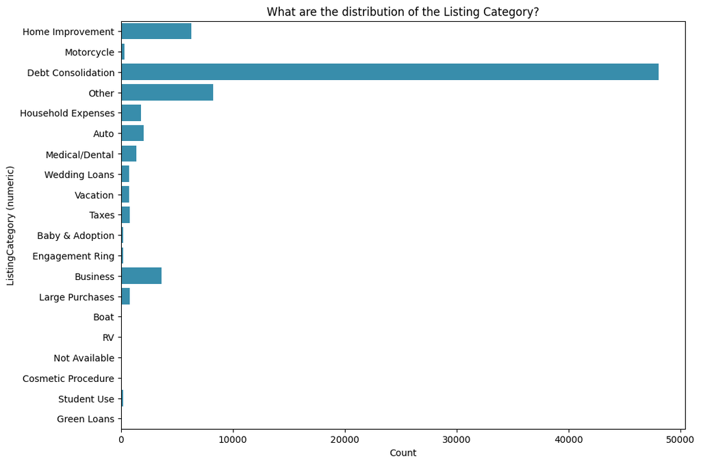

```python
plt.figure(figsize=[ 11,8])
sns.countplot(y=category_names, color='#2596be')
plt.xlabel('Count')
plt.title('What are the distribution of the Listing Category?');
```

> **It seems that the Debt Consolidation among the the Listing Category is the highest one**

#### Question2 - What is the distribution of the Loan Original Amount?

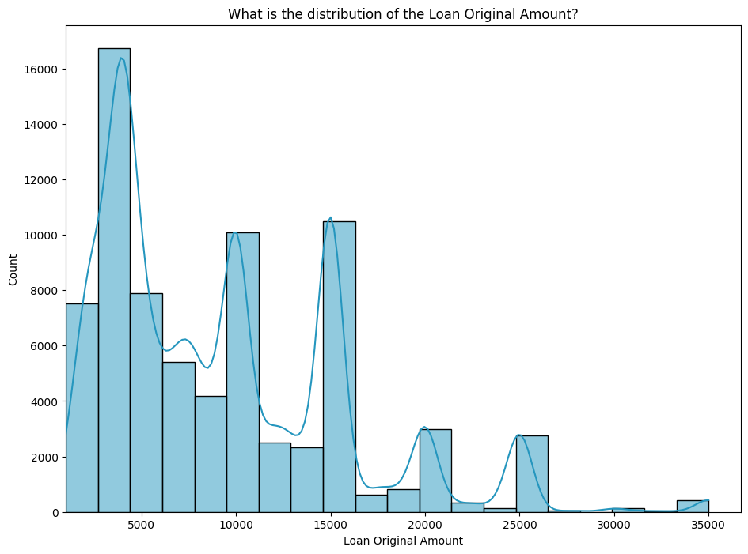

```python
plt.figure(figsize=[ 11,8])
sns.histplot(data= credit_borrower_df,  x = 'LoanOriginalAmount', bins=20, kde= True, color = '#2596be')
plt.title('What is the distribution of the Loan Original Amount?')
plt.ylabel('Count')
plt.xlim(1000)
plt.xlabel('Loan Original Amount');
```

> **The loan amounts are mostly small and have a right-skewed distribution with a few large loans standing out. This suggests there are different groups of borrowers. Even though there are some large, less common loans, they are valid and don’t need any special treatment.**

```python
borrower_states_counts = location_population_df['BorrowerState'].value_counts()

# Identify states with the minimum and maximum counts
min_count_state = borrower_states_counts.idxmin()
max_count_state = borrower_states_counts.idxmax()
min_count_value = borrower_states_counts.min()
max_count_value = borrower_states_counts.max()

# Create a DataFrame with only the min and max count states
min_max_states_df = pd.DataFrame({
    'State': [min_count_state, max_count_state],
    'Count': [min_count_value, max_count_value]
})
```

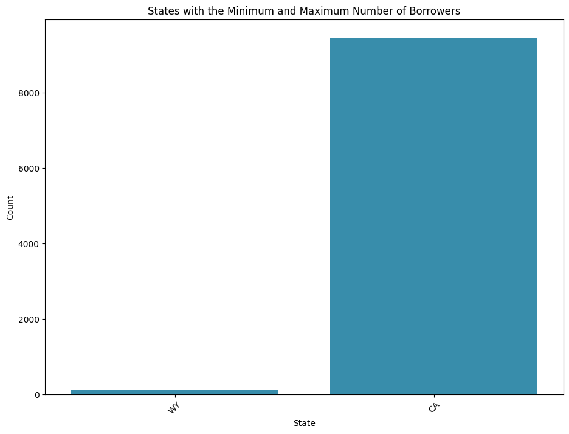

```python
plt.figure(figsize=[ 11,8])
ax = sns.barplot(x='State', y='Count', data=min_max_states_df, color='#2596be')
plt.title('States with the Minimum and Maximum Number of Borrowers')
plt.xlabel('State')
plt.xticks(rotation=45)
plt.show()
```

> **From the previous graph, we can see that California (CA) has the highest number of borrowers, while Wyoming (WY) has the lowest number.**

## Bivariate Exploration

> In this section, investigate relationships between pairs of variables in your data. Make sure the variables that you cover here have been introduced in some fashion in the previous section (univariate exploration).

#### Question 1 - Does employment status affect the Credit Score Range?

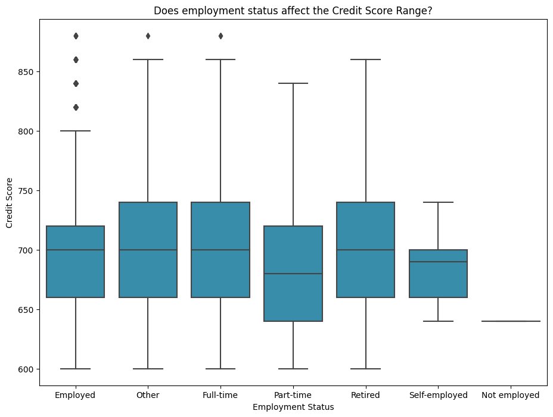

```python
plt.figure(figsize=[ 11,8])
sns.boxplot(data=credit_borrower_df, x='EmploymentStatus', y='CreditScoreRangeLower', color='#2596be')
plt.title('Does employment status affect the Credit Score Range?')
plt.xlabel('Employment Status')
plt.ylabel('Credit Score');
```

#### Question 2: How does the number of investors relate to the loan amount?

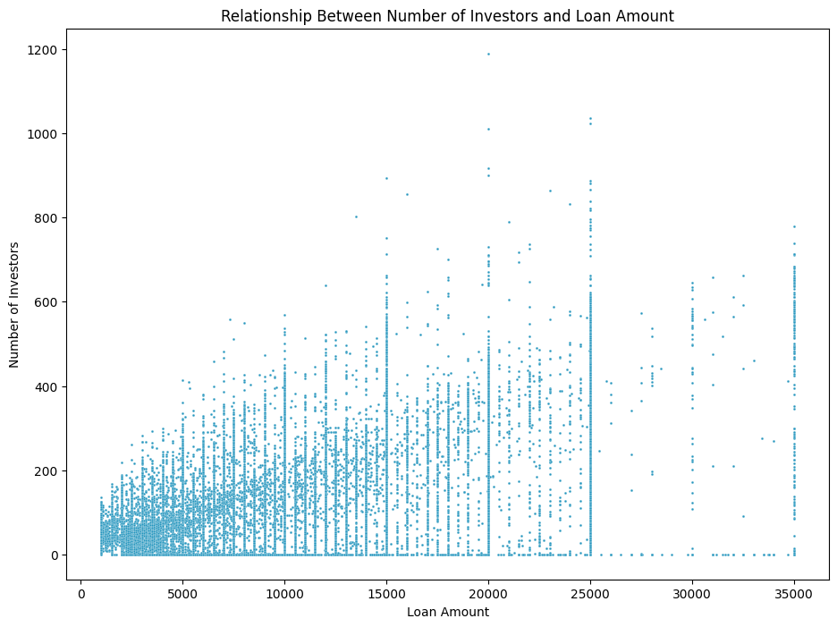

```python
plt.figure(figsize=[ 11,8])
sns.scatterplot(data=df, x='LoanOriginalAmount', y='Investors', s = 4, color='#2596be')
plt.title('Relationship Between Number of Investors and Loan Amount')
plt.xlabel('Loan Amount')
plt.ylabel('Number of Investors')
plt.show()
```

```python
correlation = df['Investors'].corr(df['LoanOriginalAmount'])
correlation
```

```
0.3209876103786074
```

> **There is a positive correlation between the number of investors and the Loan Amount, with a correlation of 0.32 This indicates that as the number of investors increases, the loan amount also tend to increase.**

> **Some outliers are observed, with loans having over 600 investors and Loan amount exceeding 25000.**

#### Qusetion 3: What is the relationship between different credit-related features and the loan amount?

```python
credit_features = [
    'CreditScoreRangeLower', 'CreditScoreRangeUpper',
    'TotalCreditLinespast7years', 'OpenRevolvingAccounts', 'DebtToIncomeRatio',
    'LoanOriginalAmount'
]


credit_features_df = df[credit_features]

correlation_matrix = credit_features_df.corr()
```

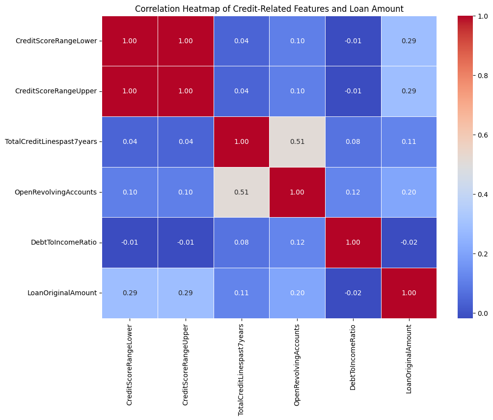

```python
plt.figure(figsize=[ 11,8])
sns.heatmap(correlation_matrix, annot=True, cmap='coolwarm', fmt='.2f', linewidths=0.5)
plt.title('Correlation Heatmap of Credit-Related Features and Loan Amount')
plt.show()
```

## Multivariate Exploration

> Create plots of three or more variables to investigate your data even further. Make sure that your investigations are justified, and follow from your work in the previous sections.

```python
df['LoanOriginalAmount_int'] = (df['LoanOriginalAmount']//10**4)*10**4
```

[figure not shown]

```python
plt.figure(figsize=[ 11,8])
sns.stripplot(data=df, x='BorrowerState', y='MonthlyLoanPayment', hue='LoanOriginalAmount_int',
              order = sorted(df['BorrowerState'].unique()),
              palette='RdYlGn_r', size = 2, jitter=0.35, dodge=True)

plt.title('Relationship between Loan Original Amount, Monthly Loan Payment, and Credit Score')
plt.xlabel('Loan Original Amount')
plt.ylabel('Monthly Loan Payment')
plt.legend(title='Loan Amount', loc='upper right', bbox_to_anchor=(1.15, 1), markerscale=3)
plt.show()
```

#### Question : How does the original loan amount vary across different income ranges and loan statuses?

```python
df['IncomeRange'].unique()
```

```
array(['$50,000-74,999', '$25,000-49,999', '$100,000+', '$75,000-99,999',
       '$1-24,999', 'Not employed'], dtype=object)
```

```python
income_range_order = ['Not employed','$1-24,999', '$25,000-49,999', '$50,000-74,999', '$75,000-99,999'
                      , '$100,000+']
```

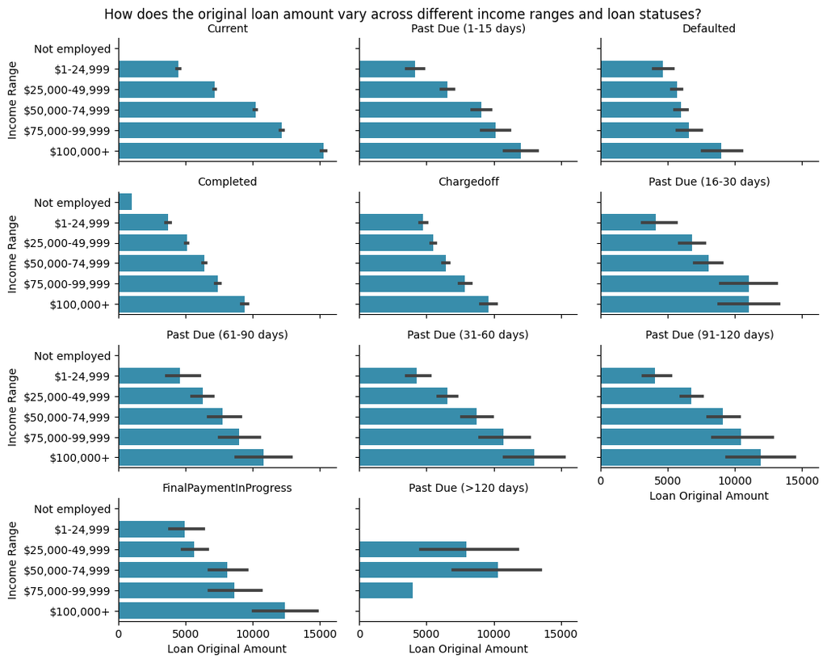

```python
## Facet Plotting three variables SimplifiedLoanStatus, LoanOriginalAmount and IncomeRange
grid = sns.FacetGrid(data = df, col = 'LoanStatus', col_wrap = 3)
grid.map(sns.barplot, 'LoanOriginalAmount', 'IncomeRange', color = '#2596be', order = income_range_order)
grid.set_titles("{col_name}")
grid.set_axis_labels('Loan Original Amount', 'Income Range')
plt.suptitle('How does the original loan amount vary across different income ranges and loan statuses?', y=1.02)
grid.figure.set_size_inches(11, 8);
```

```python
!python -m nbconvert --to html Part_I_exploration_template.ipynb
```

```
[NbConvertApp] Converting notebook Part_I_exploration_template.ipynb to html
[NbConvertApp] WARNING | Alternative text is missing on 8 image(s).
[NbConvertApp] Writing 1449438 bytes to Part_I_exploration_template.html
```